# Module 2: Build a classifier based on KNN

## Overview of KNN

Learning outcomes:

- Understand what KNN is trying to solve
- Understand how KNN works and its downsides

### Introduction to KNN algorithm

sklearn.neighbors provides functionality for unsupervised and supervised neighbors-based learning methods. Unsupervised nearest neighbors is the foundation of many other learning methods, notably manifold learning and spectral clustering. Supervised neighbors-based learning comes in two flavors: classification for data with discrete labels, and regression for data with continuous labels.

The principle behind nearest neighbor methods is to find a predefined number of training samples closest in distance to the new point, and predict the label from these. The number of samples can be a user-defined constant (k-nearest neighbor learning), or vary based on the local density of points (radius-based neighbor learning). The distance can, in general, be any metric measure: standard Euclidean distance is the most common choice. Neighbors-based methods are known as non-generalizing machine learning methods, since they simply “remember” all of its training data (possibly transformed into a fast indexing structure such as a Ball Tree or KD Tree.).

Despite its simplicity, nearest neighbors has been successful in a large number of classification and regression problems, including handwritten digits or satellite image scenes. Being a non-parametric method, it is often successful in classification situations where the decision boundary is very irregular.

The classes in sklearn.neighbors can handle either Numpy arrays or scipy.sparse matrices as input. For dense matrices, a large number of possible distance metrics are supported. For sparse matrices, arbitrary Minkowski metrics are supported for searches.

### Downsides of KNN

- High computational cost
- Weighted data points can be too high

## (Load Breast cancer dataset)

```python
import csv
import scipy
import numpy as np
from sklearn.cross_validation import train_test_split
from sklearn import preprocessing

filename = "breast-cancer-wisconsin/wdbc.data"

#Labels for the outputs
output_labels = ["M", "B"]
data = list(csv.reader(open(filename, 'rU' )))
data = scipy.array(data)

#Get predictors (X): columns 0, and 2:31
X = data[0:,2:31]
X = X.astype(np.float) #Convert to array of floats
print X

#Get targets (y): column 1
y = data[0:, 1]
print y[:10]

#Convert the labels into numerical values:
label_encoder = preprocessing.LabelEncoder()
label_encoder.fit(y) #Fit numerical values to the categorical data.
y = label_encoder.transform(y) #Transform the labels into numerical correspondents.

#Check label conversion:
print y[:10]
print 'Converted: ', y[0]

#Check all data has been successfully loaded (array shape):
print 'X dimensions: ', X.shape
print 'y dimensions: ', y.shape

from sklearn.cross_validation import train_test_split
#Split into training and test data:
X_train, X_test, y_train, y_test = train_test_split(X, y)

#Check:
print 'X_train dimensions: ', X_train.shape
print 'y_train dimensions: ', y_train.shape
print 'X_test dimensions: ', X_test.shape
print 'y_test dimensions: ', y_test.shape


outfile = "/Users/santia01/Copy/Personal_Proj_Ongoing/MyProjects/CCA_python/github/machine_learning_cca1/BCdata"
np.savez(outfile, X, y)

#npz = np.load("BCdata.npz")
#X = npz['arr_0']
#y = npz['arr_1']
```

```
[[  17.99     10.38    122.8    ...,    0.7119    0.2654    0.4601]
 [  20.57     17.77    132.9    ...,    0.2416    0.186     0.275 ]
 [  19.69     21.25    130.     ...,    0.4504    0.243     0.3613]
 ...,
 [  16.6      28.08    108.3    ...,    0.3403    0.1418    0.2218]
 [  20.6      29.33    140.1    ...,    0.9387    0.265     0.4087]
 [   7.76     24.54     47.92   ...,    0.        0.        0.2871]]
['M' 'M' 'M' 'M' 'M' 'M' 'M' 'M' 'M' 'M']
[1 1 1 1 1 1 1 1 1 1]
Converted:  1
X dimensions:  (569, 29)
y dimensions:  (569,)
X_train dimensions:  (426, 29)
y_train dimensions:  (426,)
X_test dimensions:  (143, 29)
y_test dimensions:  (143,)
```

### Learning activity 1: Find nearest neighbour with breast cancer example data

Learning outcomes:

- Understand how to run scikit-learn
- Understand how to configure KNN in scikit-learn
- Apply KNN to a real dataset

### 1.1. Introduction to classes from sklearn.neighbors library

NearestNeighbors implements unsupervised nearest neighbors learning. It acts as a uniform interface to three different nearest neighbors algorithms: BallTree, KDTree, and a brute-force algorithm based on routines in sklearn.metrics.pairwise. The choice of neighbors search algorithm is controlled through the keyword 'algorithm', which must be one of ['auto', 'ball_tree', 'kd_tree', 'brute']. When the default value 'auto' is passed, the algorithm attempts to determine the best approach from the training data.

`Warning`: Regarding the Nearest Neighbors algorithms, if two neighbors, neighbor k+1 and k, have identical distances but different labels, the results will depend on the ordering of the training data.

The Ball Tree and KD Tree have the same interface; we’ll show an example of using the ball_tree here:

```python
from sklearn import neighbors

nbrs = neighbors.NearestNeighbors(n_neighbors=3, algorithm='ball_tree').fit(X)
distances, indices = nbrs.kneighbors(X)

distances[:5,]
```

```
array([[   0.        ,  186.61762891,  194.56881063],
       [   0.        ,   16.06922748,   66.6317252 ],
       [   0.        ,   51.71676029,   54.63359015],
       [   0.        ,   38.72188787,   41.30203545],
       [   0.        ,   71.35224034,   78.89119477]])
```

```python
indices[:5]
```

```
array([[  0, 337, 254],
       [  1, 373, 323],
       [  2, 366, 487],
       [  3, 531, 488],
       [  4, 533,  78]], dtype=int32)
```

Because the query set matches the training set, the nearest neighbour of each point is the point itself, at a distance of zero. It is also possible to efficiently produce a sparse graph showing the connections between neighboring points:

```python
import numpy as np
BCgraph = nbrs.kneighbors_graph(X).toarray()
print BCgraph
print sum(BCgraph[0]) #5 neighbors
print sum(BCgraph[1])
```

```
[[ 1.  0.  0. ...,  0.  0.  0.]
 [ 0.  1.  0. ...,  0.  0.  0.]
 [ 0.  0.  1. ...,  0.  0.  0.]
 ...,
 [ 0.  0.  0. ...,  1.  0.  0.]
 [ 0.  0.  0. ...,  0.  1.  0.]
 [ 0.  0.  0. ...,  0.  0.  1.]]
3.0
3.0
```

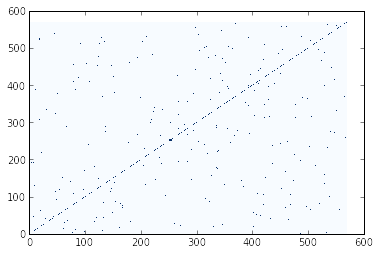

```python
%matplotlib inline

import matplotlib.pyplot as plt

#Plot heatmap of sparce
fig, ax = plt.subplots()
heatmap = ax.pcolor(BCgraph, cmap=plt.cm.Blues)
plt.show()
```

#### Exercise: Explore options available for neighbour search

```python
#n_neighbors

nbrs = neighbors.NearestNeighbors(n_neighbors=3)
nbrs = nbrs.fit(X)
distances, indices = nbrs.kneighbors(X)

print distances[:5,]
print indices[:5]

nbrs = neighbors.NearestNeighbors(n_neighbors=10).fit(X)
distances, indices = nbrs.kneighbors(X)

print distances[:5,]
print indices[:5]
```

```
[[   0.          186.61762891  194.56881063]
 [   0.           16.06922748   66.6317252 ]
 [   0.           51.71676029   54.63359015]
 [   0.           38.72188787   41.30203545]
 [   0.           71.35224034   78.89119477]]
[[  0 337 254]
 [  1 373 323]
 [  2 366 487]
 [  3 531 488]
 [  4 533  78]]
[[   0.          186.61762891  194.56881063  204.17130202  209.53711813
   220.48124076  225.49450736  232.1535111   232.27181417  232.69821408]
 [   0.           16.06922748   66.6317252    86.23022815   89.33921974
    92.56071053  121.45948401  121.6904061   123.67920693  129.61543706]
 [   0.           51.71676029   54.63359015   59.6020649    63.99285229
    72.44811544   72.77063218   73.04039729   74.16095876   90.16274221]
 [   0.           38.72188787   41.30203545   41.55840007   43.94502517
    45.70047899   46.52907515   47.01186162   48.14746419   48.21319017]
 [   0.           71.35224034   78.89119477   84.46599605   87.91102461
   112.39684312  112.53683348  113.96361731  115.45084475  115.49929784]]
[[  0 337 254  56  70 300  24 218 252 256]
 [  1 373 323 233 449 250 218 260 252 256]
 [  2 366 487 302 565 280 198 517  95 321]
 [  3 531 488 530 160 136 350 469  80 399]
 [  4 533  78 210 321 129 372 343 432 517]]
```

## Learning activity 2: Apply nearest neighbours algorithm with scikit-learn [20 min] [20 min]

Learning outcomes:

- Understand how KNN classification works
- Classify using scikit-learn implemented classifiers
- Understand differences between classifiers

### 2.1. Introduction to classifiers and how they work

Neighbors-based classification is a type of instance-based learning or non-generalizing learning: it does not attempt to construct a general internal model, but simply stores instances of the training data. Classification is computed from a simple majority vote of the nearest neighbors of each point: a query point is assigned the data class which has the most representatives within the nearest neighbors of the point.

scikit-learn implements two different nearest neighbors classifiers: KNeighborsClassifier implements learning based on the k nearest neighbors of each query point, where k is an integer value specified by the user. RadiusNeighborsClassifier implements learning based on the number of neighbors within a fixed radius r of each training point, where r is a floating-point value specified by the user.

#### KNeighborsClassifier

The k-neighbors classification in KNeighborsClassifier is the more commonly used of the two techniques. The optimal choice of the value k is highly data-dependent: in general a larger k suppresses the effects of noise, but makes the classification boundaries less distinct.

#### RadiusNeighborsClassifier

In cases where the data is not uniformly sampled, radius-based neighbors classification in RadiusNeighborsClassifier can be a better choice. The user specifies a fixed radius r, such that points in sparser neighborhoods use fewer nearest neighbors for the classification. For high-dimensional parameter spaces, this method becomes less effective due to the so-called “curse of dimensionality”.

### 2.2. Calssification

```python
#Classification based on 3 nearest neighbours
knnK3 = neighbors.KNeighborsClassifier(n_neighbors=3)
knnK3 = knnK3.fit(X, y)
predictedK = knnK3.predict(X)

#Classification based on 15 nearest neighbours
knnK15 = neighbors.KNeighborsClassifier(n_neighbors=15)
knnK15= knnK15.fit(X, y)
predictedK15 = knnK15.predict(X)
```

#### Weights

The basic nearest neighbors classification uses uniform weights: that is, the value assigned to a query point is computed from a simple majority vote of the nearest neighbors. Under some circumstances, it is better to weight the neighbors such that nearer neighbors contribute more to the fit. This can be accomplished through the weights keyword. The default value, weights = 'uniform', assigns uniform weights to each neighbor. weights = 'distance' assigns weights proportional to the inverse of the distance from the query point. Alternatively, a user-defined function of the distance can be supplied which is used to compute the weights.

```python
#Classification based on 3 nearest neighbours
knn = neighbors.KNeighborsClassifier(n_neighbors=3, weights='distance')
knn = knn.fit(X, y)
```

## Learning activity 3: Calculate the accuracy and recall scores of your classifier [20min]

Learning outcomes:

- Know the metrics by which models can be evaluated
- Understand how to evaluate performance in terms of accuracy and recall
- Know how to use cross validation

### 3.2. Compare number of correct predictions (loop) - Demonstrate classification result

```python
from sklearn.cross_validation import train_test_split

#Split into training and test data:
XTrain, XTest, yTrain, yTest = train_test_split(X, y)

#Check:
print 'XTrain dimensions: ', XTrain.shape
print 'yTrain dimensions: ', yTrain.shape
print 'XTest dimensions: ', XTest.shape
print 'yTest dimensions: ', yTest.shape
```

```
XTrain dimensions:  (426, 29)
yTrain dimensions:  (426,)
XTest dimensions:  (143, 29)
yTest dimensions:  (143,)
```

```python
from sklearn import neighbors
knn = neighbors.KNeighborsClassifier(n_neighbors=3)
knn.fit(XTrain, yTrain)

predicted = knn.predict(XTest)

from sklearn import metrics
mat = metrics.confusion_matrix(yTest, predicted)
mat
```

```
array([[83,  7],
       [ 8, 45]])
```

```python
a = np.array(map(str, zip(yTest,predicted)))

tp = sum(a == '(0, 0)')
tn = sum(a == '(1, 1)')
fp = sum(a == '(1, 0)')
fn = sum(a == '(0, 1)')
print "true positives", tp
print "true negatives", tn
print "false positives", fp
print "false negatives", fn

print "correct calls:", sum(yTest == predicted)
print "correct calls:", tp+tn
print "number of classifications:", yTest.size

#Accuracy is the total of correct calls / total of classifications
accuracy = sum(yTest == predicted) / float(yTest.size)

#Precision is the number of true positives / total number of elements the 'predicted' class
precisionM = mat[0,0] / float(mat[0,0]+mat[1,0])
precisionB = mat[1,1] / float(mat[0,1]+mat[1,1])

#Recall is the number of true positives / total number of elements the 'known' class
recallM = mat[0,0] / float(mat[0,0]+mat[0,1])
recallB = mat[1,1] / float(mat[1,0]+mat[1,1])

#print out
print "accuracy:", accuracy
print "precision for class M:", round(precisionM,2)
print "precision for class B:", round(precisionB,2)
print "recall for class M:", round(recallM,2)
print "recall for class B:", round(recallB,2)
```

```
true positives 83
true negatives 45
false positives 8
false negatives 7
correct calls: 128
correct calls: 128
number of classifications: 143
accuracy: 0.895104895105
precision for class M: 0.91
precision for class B: 0.87
recall for class M: 0.92
recall for class B: 0.85
```

```python
from sklearn import metrics
print metrics.classification_report(yTest, predicted)
print 'accuracy:', knn.score(XTest, yTest)
#print metrics.f1_score(yTest, predicted)
```

```
             precision    recall  f1-score   support

          0       0.91      0.92      0.92        90
          1       0.87      0.85      0.86        53

avg / total       0.89      0.90      0.89       143

accuracy: 0.895104895105
```

#### Use randomised data

Compare with model trained on randomised X data:

```python
import numpy

perm = np.random.permutation(y_train.size)
X_random = numpy.copy(X_train)[perm]

knn2 = neighbors.KNeighborsClassifier()

#Compare with model trained on randomised X data:
knn2 = knn2.fit(X_random, y_train)
predicted = knn2.predict(X_random)
print float(sum(y_train != predicted))/len(y_train)
print 'Proportion mislabeled random model: %.5f'  %(1- knn2.score(X_random, y_train))
```

```
0.284037558685
Proportion mislabeled random model: 0.28404
```

## Learning activity 4: Demonstrate the classification result by plotting accuracy for different options

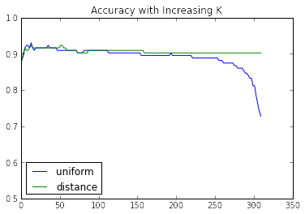

```
[(array([ 1.        ,  0.88111888]), array([ 1.        ,  0.88111888])),
 (array([ 3.       ,  0.8951049]), array([ 3.       ,  0.9020979])),
 (array([ 5.        ,  0.91608392]), array([ 5.        ,  0.91608392])),
 (array([ 7.        ,  0.92307692]), array([ 7.        ,  0.90909091])),
 (array([ 9.        ,  0.92307692]), array([ 9.        ,  0.90909091])),
 (array([ 11.        ,   0.91608392]), array([ 11.        ,   0.91608392])),
 (array([ 13.        ,   0.93006993]), array([ 13.        ,   0.92307692])),
 (array([ 15.        ,   0.91608392]), array([ 15.        ,   0.91608392])),
 (array([ 17.        ,   0.90909091]), array([ 17.        ,   0.91608392])),
 (array([ 19.        ,   0.91608392]), array([ 19.        ,   0.91608392]))]
```

```python
%matplotlib inline


#use different distance metrics
#http://blog.yhathq.com/posts/classification-using-knn-and-python.html

import matplotlib.pyplot as plt
from sklearn import neighbors

def plotvector(XTrain, yTrain, XTest, yTest, weights):
    results = []

    #Xtrain = XTrain[:, :2]

    for n in range(1, 310, 2):
        clf = neighbors.KNeighborsClassifier(n_neighbors=n, weights=weights)
        clf = clf.fit(XTrain, yTrain)
        preds = clf.predict(XTest)
        accuracy = clf.score(XTest, yTest)
        results.append([n, accuracy])

    results = np.array(results)
    return(results)

pltvector1 = plotvector(XTrain, yTrain, XTest, yTest, weights="uniform")
pltvector2 = plotvector(XTrain, yTrain, XTest, yTest, weights="distance")
#pltvector3 = plotvector(XTrain, yTrain, XTest, yTest, weights="uniform",algorithm="kd_tree")
#pltvector4 = plotvector(XTrain, yTrain, XTest, yTest, weights="distance",algorithm="kd_tree")
line1 = plt.plot(pltvector1[:,0], pltvector1[:,1], label="uniform")
line2 = plt.plot(pltvector2[:,0], pltvector2[:,1],  label="distance")
#line3 = plt.plot(pltvector3[:,0], pltvector3[:,1], label="uniform_KDtree")
#line4 = plt.plot(pltvector4[:,0], pltvector4[:,1],  label="distance_KDtree")
plt.legend(loc=3)
plt.ylim(0.5, 1)
plt.title("Accuracy with Increasing K")
plt.show()

zip(pltvector1[:10],pltvector2[:10])
```

### Demonstrate the classification result by ploting the decision boundery

Sample usage of Nearest Neighbors classification. It will plot the decision boundaries for each class:

```python
#code taken from: http://scikit-learn.org/stable/auto_examples/neighbors/plot_classification.html#example-neighbors-plot-classification-py

import matplotlib.pyplot as plt
from matplotlib.colors import ListedColormap

def decision_plot(XTrain, yTrain, n_neighbors, weights):
    h = .02  # step size in the mesh

    Xtrain = XTrain[:, :2] # we only take the first two features.

    # Create color maps
    cmap_light = ListedColormap(['#FFAAAA', '#AAFFAA', '#AAAAFF'])
    cmap_bold = ListedColormap(['#FF0000', '#00FF00', '#0000FF'])

    clf = neighbors.KNeighborsClassifier(n_neighbors, weights=weights)
    clf.fit(Xtrain, yTrain)

    # Plot the decision boundary. For that, we will assign a color to each
    # point in the mesh [x_min, m_max]x[y_min, y_max].
    x_min, x_max = Xtrain[:, 0].min() - 1, Xtrain[:, 0].max() + 1
    y_min, y_max = Xtrain[:, 1].min() - 1, Xtrain[:, 1].max() + 1
    xx, yy = np.meshgrid(np.arange(x_min, x_max, h),
                         np.arange(y_min, y_max, h))
    Z = clf.predict(np.c_[xx.ravel(), yy.ravel()])

    # Put the result into a color plot
    Z = Z.reshape(xx.shape)
    plt.figure()
    plt.pcolormesh(xx, yy, Z, cmap=cmap_light)

    # Plot also the training points
    plt.scatter(Xtrain[:, 0], Xtrain[:, 1], c=yTrain, cmap=cmap_bold)
    plt.xlim(xx.min(), xx.max())
    plt.ylim(yy.min(), yy.max())
    plt.title("2-Class classification (k = %i, weights = '%s')"
              % (n_neighbors, weights))
    plt.show()
```

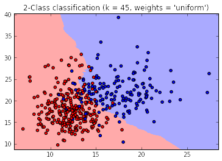

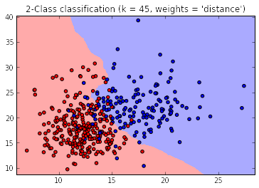

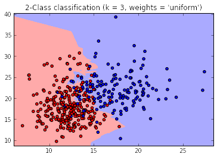

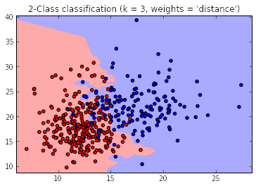

```python
%matplotlib inline

decision_plot(XTrain, yTrain, n_neighbors=45, weights='uniform')
decision_plot(XTrain, yTrain, n_neighbors=45, weights='distance')
decision_plot(XTrain, yTrain, n_neighbors=3, weights='uniform')
decision_plot(XTrain, yTrain, n_neighbors=3, weights='distance')
```

## Learning activity 5: Implement k-fold cross-validation for your model

```python
print XTrain.shape
print XTest.shape
```

```
(426, 29)
(143, 29)
```

```python
from sklearn import cross_validation

#Cross validation score
from sklearn import cross_validation
scores = cross_validation.cross_val_score(knn, XTrain, yTrain, cv=5)
print "split into 5:", scores

#Cross validation score (leave one out)
#from sklearn.cross_validation import cross_val_score
#scores = cross_val_score(knn, XTrain, yTrain, cv=yTrain.size) #the same as leave one out
#print "Leave one out:", scores
```

```
split into 5: [ 0.90697674  0.96470588  0.97647059  0.95294118  0.91764706]
```

```python
scores
```

```
array([ 0.90697674,  0.96470588,  0.97647059,  0.95294118,  0.91764706])
```

```python
scores.mean()
```

```
0.94374829001367999
```

# Further reading

- http://scikit-learn.org/stable/modules/neighbors.html#nearest-neighbor-algorithms - For a discussion of the strengths and weaknesses of each option, see Nearest Neighbor Algorithms.
- http://scikit-learn.org/stable/modules/generated/sklearn.neighbors.KNeighborsClassifier.html - KNeighborsClassifier documentation